# Assignment 2

Hari Subhash

Date created: 2019-04-18

**Due Date**: Sunday, April 28th

**Keyboard Shortcuts**:

1. Assignment operator (<-) is `Alt+-` for Windows and `Option+-` for Mac
2. Insert new code chunk `Ctrl+Alt+I` for Windows and `Command+Option+I` for Mac
3. Run a line of code `Ctrl+Enter` for Windows and `Command+Enter` for Mac
4. Run all the code within a chunk `Ctrl+Shift+Enter` for Windows and `Command+Shift+Enter` for Mac
5. Insert a pipe operator (%>%) `Ctrl+Shift+M` for Windows and `Command+Shift+M` for Mac

**General Instructions**

1. Create a new notebook (copy parts of the YAML header you are interested in keeping) to work on your assignment.
2. The assignment should be submitted via a shareable github link that points to your notebook (.nb.html) file to me on Slack.
3. Make sure the notebook is neatly formatted, and that all the charts and tables and look good when you preview it.

**Task**: Explore at least 5 different causes for departure and arrival delays (combined - not 5 each). Its not necessary that you find a definitive answer for what causes a delay, instead I want you to showcase your ability to explore the data with a combination of analytical text, tables and charts. The final output should be something you can show a prospective employer or client as proof of you ability to work with data in R.

```r
library(tidyverse); library(nycflights13); library(skimr)
```

Hypothesis: Larger planes (as measured by seating) are more frequently delayed

Lets take a look at the planes dataset.

| tailnum | year | type | manufacturer | model | engines | seats | speed | engine |
| --- | --- | --- | --- | --- | --- | --- | --- | --- |
| N10156 | 2004 | Fixed wing multi engine | EMBRAER | EMB-145XR | 2 | 55 | NA | Turbo-fan |
| N102UW | 1998 | Fixed wing multi engine | AIRBUS INDUSTRIE | A320-214 | 2 | 182 | NA | Turbo-fan |
| N103US | 1999 | Fixed wing multi engine | AIRBUS INDUSTRIE | A320-214 | 2 | 182 | NA | Turbo-fan |
| N104UW | 1999 | Fixed wing multi engine | AIRBUS INDUSTRIE | A320-214 | 2 | 182 | NA | Turbo-fan |
| N10575 | 2002 | Fixed wing multi engine | EMBRAER | EMB-145LR | 2 | 55 | NA | Turbo-fan |
| N105UW | 1999 | Fixed wing multi engine | AIRBUS INDUSTRIE | A320-214 | 2 | 182 | NA | Turbo-fan |
| N107US | 1999 | Fixed wing multi engine | AIRBUS INDUSTRIE | A320-214 | 2 | 182 | NA | Turbo-fan |
| N108UW | 1999 | Fixed wing multi engine | AIRBUS INDUSTRIE | A320-214 | 2 | 182 | NA | Turbo-fan |
| N109UW | 1999 | Fixed wing multi engine | AIRBUS INDUSTRIE | A320-214 | 2 | 182 | NA | Turbo-fan |
| N110UW | 1999 | Fixed wing multi engine | AIRBUS INDUSTRIE | A320-214 | 2 | 182 | NA | Turbo-fan |

[output cut: 990 more lines]

```r
skimr::skim(planes)
```

```
Skim summary statistics
 n obs: 3322
 n variables: 9

── Variable type:character ──────────────────────────────────────────────────────────────────────────────────────────────────
     variable missing complete    n min max empty n_unique
       engine       0     3322 3322   7  13     0        6
 manufacturer       0     3322 3322   4  29     0       35
        model       0     3322 3322   2  18     0      127
      tailnum       0     3322 3322   5   6     0     3322
         type       0     3322 3322  10  24     0        3

── Variable type:integer ────────────────────────────────────────────────────────────────────────────────────────────────────
 variable missing complete    n    mean     sd   p0    p25  p50  p75 p100     hist
  engines       0     3322 3322    2      0.12    1    2      2    2    4 ▁▁▇▁▁▁▁▁
    seats       0     3322 3322  154.32  73.65    2  140    149  182  450 ▃▂▇▇▁▁▁▁
    speed    3299       23 3322  236.78 149.76   90  107.5  162  432  432 ▇▂▁▁▁▁▁▆
     year      70     3252 3322 2000.48   7.19 1956 1997   2001 2005 2013 ▁▁▁▁▂▃▇▅
```

Lets take a closer look at our explanatory variable.

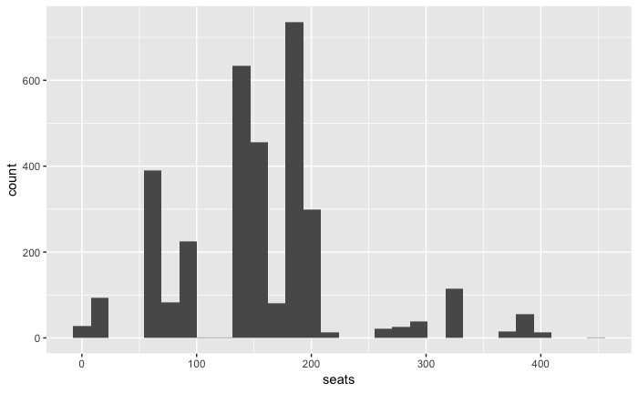

| year | month | day | dep_time | sched_dep_time | dep_delay | arr_time | sched_arr_time | arr_delay | carrier | flight | tailnum | origin | dest | air_time | distance | hour | minute | time_hour |
| --- | --- | --- | --- | --- | --- | --- | --- | --- | --- | --- | --- | --- | --- | --- | --- | --- | --- | --- |
| 2013 | 1 | 1 | 517 | 515 | 2 | 830 | 819 | 11 | UA | 1545 | N14228 | EWR | IAH | 227 | 1400 | 5 | 15 | 2013-01-01 05:00:00 |
| 2013 | 1 | 1 | 533 | 529 | 4 | 850 | 830 | 20 | UA | 1714 | N24211 | LGA | IAH | 227 | 1416 | 5 | 29 | 2013-01-01 05:00:00 |
| 2013 | 1 | 1 | 542 | 540 | 2 | 923 | 850 | 33 | AA | 1141 | N619AA | JFK | MIA | 160 | 1089 | 5 | 40 | 2013-01-01 05:00:00 |
| 2013 | 1 | 1 | 544 | 545 | -1 | 1004 | 1022 | -18 | B6 | 725 | N804JB | JFK | BQN | 183 | 1576 | 5 | 45 | 2013-01-01 05:00:00 |
| 2013 | 1 | 1 | 554 | 600 | -6 | 812 | 837 | -25 | DL | 461 | N668DN | LGA | ATL | 116 | 762 | 6 | 0 | 2013-01-01 06:00:00 |
| 2013 | 1 | 1 | 554 | 558 | -4 | 740 | 728 | 12 | UA | 1696 | N39463 | EWR | ORD | 150 | 719 | 5 | 58 | 2013-01-01 05:00:00 |
| 2013 | 1 | 1 | 555 | 600 | -5 | 913 | 854 | 19 | B6 | 507 | N516JB | EWR | FLL | 158 | 1065 | 6 | 0 | 2013-01-01 06:00:00 |
| 2013 | 1 | 1 | 557 | 600 | -3 | 709 | 723 | -14 | EV | 5708 | N829AS | LGA | IAD | 53 | 229 | 6 | 0 | 2013-01-01 06:00:00 |
| 2013 | 1 | 1 | 557 | 600 | -3 | 838 | 846 | -8 | B6 | 79 | N593JB | JFK | MCO | 140 | 944 | 6 | 0 | 2013-01-01 06:00:00 |
| 2013 | 1 | 1 | 558 | 600 | -2 | 753 | 745 | 8 | AA | 301 | N3ALAA | LGA | ORD | 138 | 733 | 6 | 0 | 2013-01-01 06:00:00 |

[output cut: 990 more lines]

Now lets also look at the dep_delay

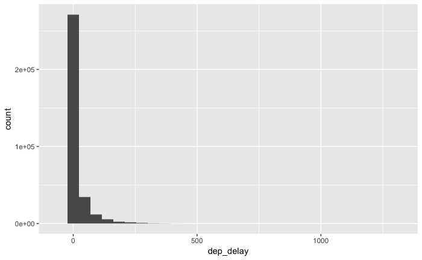

Now lets join the planes data with the flights. I am only interested in rows with both dep delay and seating info. I am also only interested in positive delays.

```r
seatingData <- inner_join(flights,
           planes %>%
               rename(yearMfg = year),
           by = "tailnum") %>%
    filter(dep_delay > depThreshold) %>%
    group_by(seats) %>%
    ##lets remove groups which have less than 20 obs.
    filter(n() > 20) %>%
    ungroup()
```

```
Error: object 'depThreshold' not found
```

Lets look at a table with some summary stats grouped by seating.

| seats | nObs | meanDelay |
| --- | --- | --- |
| 377 | 21 | 136.14286 |
| 147 | 32 | 127.50000 |
| 8 | 25 | 107.16000 |
| 100 | 717 | 85.11994 |
| 142 | 1705 | 84.37947 |
| 80 | 2088 | 80.14751 |
| 255 | 605 | 80.04132 |
| 95 | 2938 | 79.62560 |
| 182 | 2027 | 79.42033 |
| 172 | 544 | 77.08088 |

[output cut: 21 more lines]

This chart is not telling me a compelling story yet.

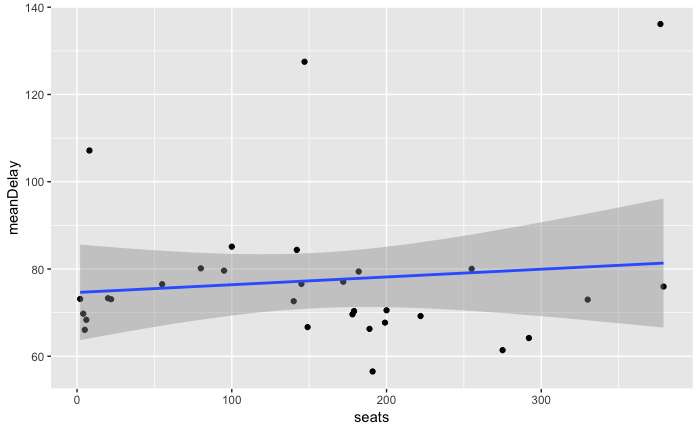

I would like to maybe work with the raw data instead of summarised.

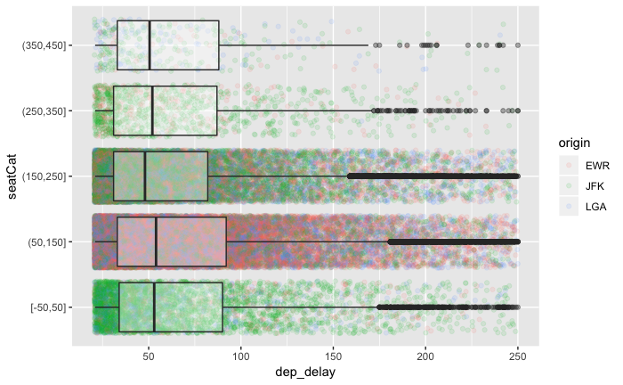